# 013E01 Executive Summary

John Fu

Lim Joanne

# Data set

The data set we use in our analysis was originally collected by SOCR to estimate the percentage of body fat determined by underwater weighing and various body circumference measurements for 250 men.

There are 16 variables included in the data and the key dependent variable for this analysis is `Pct.BF` - a variable measuring percentage body fat of men.

# Analysis

Our modeling began by first eliminating the ‘density’ variable from the data set due to its challenging nature of measurement in real-world settings and limited practical utility. Following this, we employed both backward and forward selection model based on the AIC to identify the optimal predictors for body fat percentage.

For backward selection, we firstly run a full regression model which contains all the explanatory variables in our data set. Then we try to drop variables to lower the AIC, and this narrowed down to eight key predictors: Age, Height, Neck, Abdomen, Hip Thigh, Forearm and Wrist.

Conversely, the forward selection began without any predictors, incrementally adding the most statistically significant ones. This process ended up including six predictors: Waist, Weight, Wrist, Bicep, Age and Thigh.

In conclusion, backward selection model appears to be more compelling with its slightly higher adjusted R-squared value and lower AIC value.

# Assumptions

Before proceed to analyse our models results, we must first ensure that all our assumptions are satisfied. The key assumptions for our model are: 1. Linearity - the relationship between Y and x is linear. 2. Independence - all the errors are independent of each other. 3. Homoskedasticity - the errors have constant variance. 4. Normality - the error follows a normal distribution.

# Results

Our final model is:

$$\begin{align*}
\widehat{Pct.BF} &= 5.04 + 0.0726 \times Age - 0.268 \times Height -
0.451 \times Neck \\
&\quad + 0.822 \times Abdomen - 0.195 \times Hip +
0.224 \times Thigh \\
&\quad + 0.295 \times Forearm - 1.731 \times Wrist
\end{align*}$$

Making all the explanatory variables equal to zero, on average the predicted percentage body fat is 5.04%. Holding other variables constant, a year increase in age will leads to a 0.07 increase in body fat percentage. Holding all other variables constant, a 1cm increase in Height, on average would have a predicted decrease in body fat percentage by 0.268%. Holding other variables constant, a 1cm increase in Neck circumference, on average body fat percentage will decrease by 0.451%. Holding other variables constant, a 1cm increase in Abdomen circumference will lead to 0.822% increase in body fat percentage. Holding all variables constant, a 1cm increase in Hip circumference, on average would have a predicted decrease in body fat percentage by 0.195%. Holding other variables constant, a 1cm increase in Thigh circumference will lead to 0.224% increase in body fat percentage. Holding other variables constant, a 1cm increase in Forearm circumference will lead to 0.295% increase in body fat percentage. Holding other variables constant, a 1cm increase in Wrist circumference, on average body fat percentage will decrease by 1.731%.

# Appendix 2

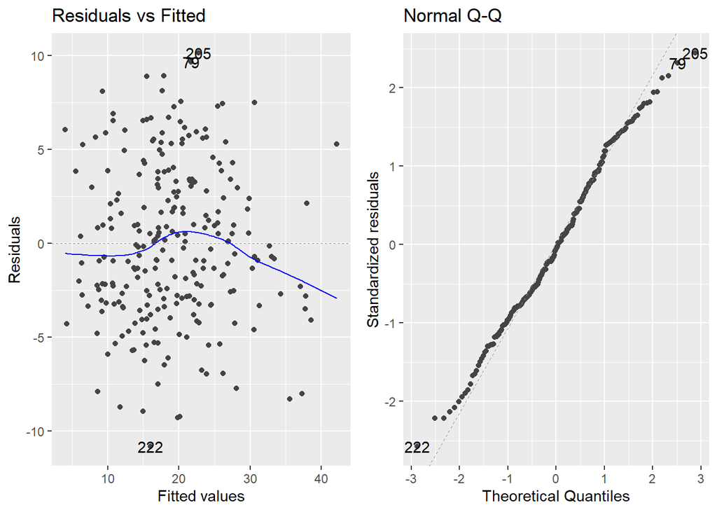

# Appendix 3

## Full Model

```
## Linear Regression
##
## 250 samples
##  14 predictor
##
## No pre-processing
## Resampling: Cross-Validated (10 fold)
## Summary of sample sizes: 224, 225, 224, 226, 225, 224, ...
## Resampling results:
##
##   RMSE      Rsquared   MAE
##   4.345675  0.7245596  3.596767
##
## Tuning parameter 'intercept' was held constant at a value of TRUE
```

## Simple Model

```
## Linear Regression
##
## 250 samples
##   8 predictor
##
## No pre-processing
## Resampling: Cross-Validated (10 fold)
## Summary of sample sizes: 226, 224, 224, 225, 225, 225, ...
## Resampling results:
##
##   RMSE      Rsquared  MAE
##   4.233898  0.742006  3.502025
##
## Tuning parameter 'intercept' was held constant at a value of TRUE
```